# STA304H1F/1003HF Fall 2018 Assignment

RyanYip

2018年10月25日

# Exercise 1

## Load data

```r
certify=read.csv("./certify.csv",header = TRUE)
summary(certify)
```

```
##     certify         approve         speccert        wouldyou
##  Min.   :0.000   Min.   :0.000   Min.   :0.000   Min.   :0.000
##  1st Qu.:1.000   1st Qu.:2.000   1st Qu.:2.000   1st Qu.:1.000
##  Median :3.000   Median :3.000   Median :5.000   Median :2.000
##  Mean   :3.078   Mean   :3.252   Mean   :3.687   Mean   :2.803
##  3rd Qu.:5.000   3rd Qu.:5.000   3rd Qu.:5.000   3rd Qu.:5.000
##  Max.   :5.000   Max.   :5.000   Max.   :5.000   Max.   :5.000
##
##      recert         subdisc     college  employ   workenv  workact
##  Min.   :0.000   BI     : 940   B: 234   E:3943   A:2005   C: 985
##  1st Qu.:2.000   BP     : 518   M:1515   I: 166   G: 826   E: 862
##  Median :3.000   BE     : 501   N:  15   O:   1   I:1716   O:   7
##  Mean   :3.275   PE     : 448   O:   2   R: 181   O:   1   P:1030
##  3rd Qu.:5.000   QP     : 326   P:2782   S: 219            R:1515
##  Max.   :5.000   CM     : 310            U:  38            S: 149
##                  (Other):1505
##     yearsmem
##  Min.   : 0.00
##  1st Qu.: 5.00
##  Median :12.00
##  Mean   :13.62
##  3rd Qu.:20.00
##  Max.   :62.00
##
```

** Summary ** function show each variable’s value in * Min,1st Qu,Median,3rd qu,Max *

## (a)

```r
set.seed(20181025) # set seed

#Take a simple random sample without replacement of size 100
idx=sample(1:dim(certify)[1],size = 100,replace = FALSE)
sub.certify=certify[idx,]



#estimate the proportion of respondents who think that ASA should develop some form of certification (YES=1)
n_yes=sum(sub.certify$certify==1)
prob=n_yes/dim(sub.certify)[1]
sprintf("the proportion
of respondents who think that ASA should develop some form of certification is : %f",prob)
```

```
## [1] "the proportion\nof respondents who think that ASA should develop some form of certification is : 0.230000"
```

## (b)

- 1. the sample proportion:p_hat=x/n
- 2. z-score:(p_hat-p)/sqrt(pq/n),where q=1-p
- 3. E=z_alpha_2* sqrt(pq/n)
- 4. **alpha** confidence interval: p_hat-E<p<p_hat+E,and E=z_alpha_2*sqrt(p_hat x q_hat/n)

```r
alpha=1-0.95
n=dim(sub.certify)[1]
p_hat=n_yes/n
q_hat=1-p_hat

z_alpha_2=qnorm(p=1-alpha/2)
E=z_alpha_2*sqrt(p_hat*q_hat/n)

var_p_hat=p_hat*q_hat/n  # var(p_hat),p_hat variance
lower=p_hat-E  # lower confidence interval
upper=p_hat+E  # upper confidence interval
```

Follow the above analysis,the variance p_hat is 0.001771,the 95% confidence interval is (0.1475183,0.3124817)

## (c)

We have know that,** E=z_alpha_2 x sqrt(p_hat*q_hat/n) **,in this,n(to be estimated) is not know,the p_hat be estimated in part(a).part(c) tells us that B=5%.

Get: 0.025=E,where p_hat,q_hat,z_alpha we can know,so n=1/(0.025/z_alpha_2)**2 x (p_hat x q_hat)

```r
B=0.05
z_alpha=qnorm(1-B/2)

n_hat=ceiling(1/(0.025/z_alpha_2)**2 * (p_hat * q_hat))
sprintf("the sample size n be estimated is about:%f",n_hat)
```

```
## [1] "the sample size n be estimated is about:1089.000000"
```

So we would need a sample of about 1100 sample.

## (d)

Recalculate parts (a) and (b) using the sample size *n_hat* 1089 obtained in part (c)

### recaculate part(a)

```r
set.seed(20181025) # set seed

#Take a simple random sample without replacement of size 100
idx=sample(1:dim(certify)[1],size = n_hat,replace = FALSE)
sub.certify=certify[idx,]



#estimate the proportion of respondents who think that ASA should develop some form of certification (YES=1)
n_yes=sum(sub.certify$certify==1)
prob=n_yes/dim(sub.certify)[1]
sprintf("the proportion of respondents who think that ASA should develop some form of certification is : %f",prob)
```

```
## [1] "the proportion of respondents who think that ASA should develop some form of certification is : 0.265381"
```

### recaculate part(b)

```r
alpha=1-0.95
n=dim(sub.certify)[1]
p_hat=n_yes/n
q_hat=1-p_hat

z_alpha_2=qnorm(p=1-alpha/2)
E=z_alpha_2*sqrt(p_hat*q_hat/n)

var_p_hat=p_hat*q_hat/n  # var(p_hat),p_hat variance
lower=p_hat-E  # lower confidence interval
upper=p_hat+E  # upper confidence interval
sprintf("the confidence interval range is :%f",upper-lower)
```

```
## [1] "the confidence interval range is :0.052448"
```

Follow the above analysis,the variance p_hat is 1.790210910^{-4},the 95% confidence interval is (0.239157,0.2916052),the confidence interval range is 0.0524482

# Exercise 2

## Load data

```r
goals=read.csv("./goals.csv",header = TRUE)
summary(goals)
```

```
##      index            goal
##  Min.   :  1.0   Min.   : 50.00
##  1st Qu.: 63.5   1st Qu.: 80.00
##  Median :126.0   Median : 85.00
##  Mean   :126.0   Mean   : 84.12
##  3rd Qu.:188.5   3rd Qu.: 90.00
##  Max.   :251.0   Max.   :100.00
```

## (a)

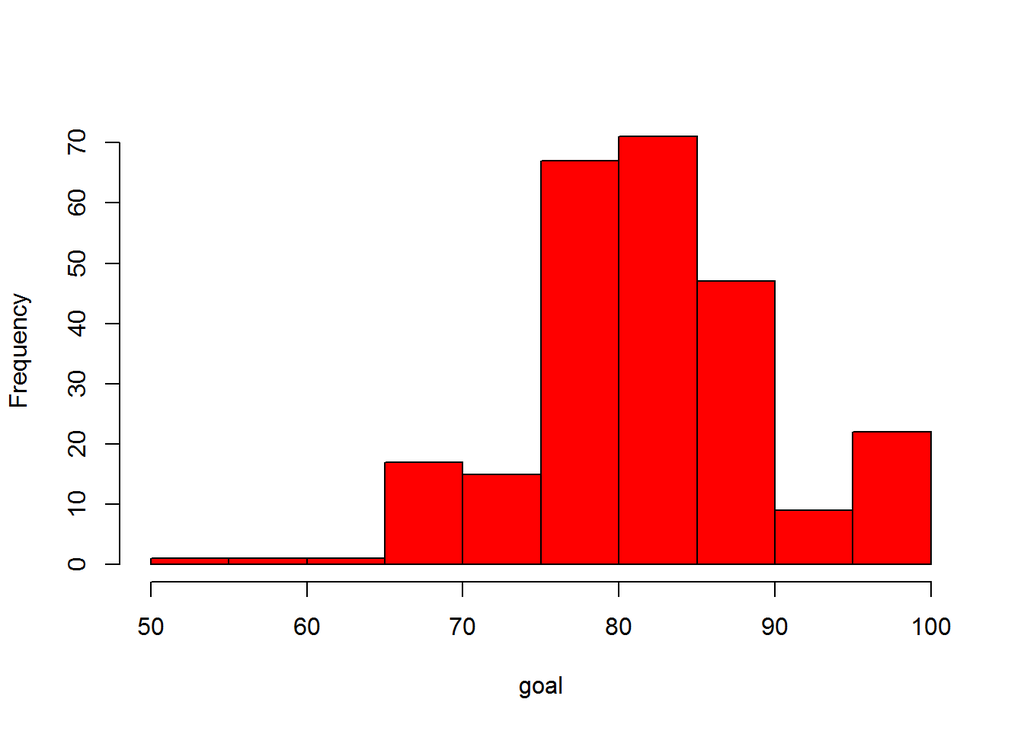

```r
goal_mean=mean(goals$goal) # cacualate population mean
goal_var=var(goals$goal) # caculate population variance

hist(goals$goal,xlab = "goal",main=NULL,col="red")  # Draw a histogram
```

The population mean is 84.1155378,population variance is 64.3665976.and the histogram show us that the center of goal is about 80,proportion of lower goal(50,60) is lower.

## (b)

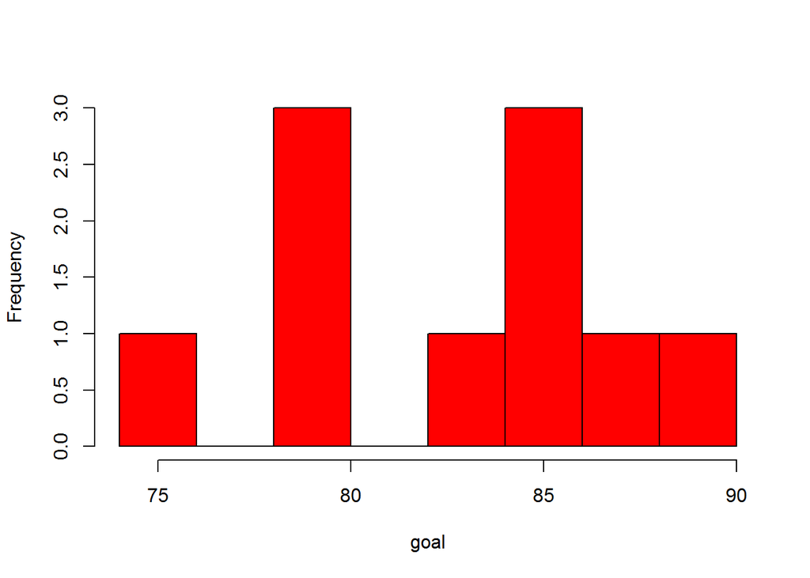

```r
set.seed(20181026)
goal=goals$goal

idx_raw=sample(1:length(goal),size=10,replace = FALSE)
goal_1=goal[idx_raw]#  Select a simple random sample of 10 grades.

goal_1_mean=mean(goal_1)
goal_1_var=var(goal_1)

hist(goal_1,xlab = "goal",main=NULL,col="red",breaks = 10)  # Draw a histogram
```

the sample mean is 83.1,sample variance is 19.6555556

## (c)

#### Repeat part (b) 49 additional times and combine to have 50 sample means

```r
goal_sample=data.frame(sample_1=goal_1)
idx_raw=data.frame(idx_1=idx_raw)
RepeatSample<-function(raw=goal_sample,idx=idx_raw,size=10,times=49){
  for(i in 1:times){
    idx=sample(1:length(goal),size=size,replace = FALSE)
    sample_x=data.frame(goal[idx])
    sample_idx=data.frame(idx)

    colnames(sample_x)=paste0("sample_",i+1)
    colnames(sample_idx)=paste0("idx_",i+1)
    raw=cbind.data.frame(raw,sample_x)
    idx_raw=cbind.data.frame(idx_raw,sample_idx)
  }

  return(list(raw,idx_raw))
}

goal_sample=RepeatSample(raw = goal_sample)
```

#### Draw a histogram to describe your 50 sample means.

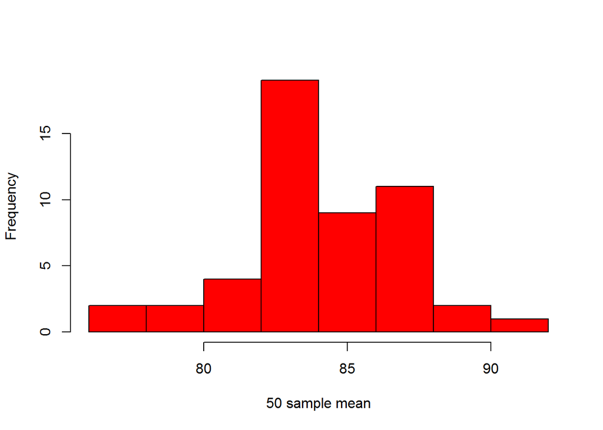

```r
goal_sample_mean=apply(goal_sample[[1]],2,mean) #  50 sample mean
goal_sample_var=apply(goal_sample[[1]],2,var) # 50 sample variance

goal_sample_index=goal_sample[[2]]  # the index positions of your 50 samples
hist(goal_sample_mean,xlab = "50 sample mean",main=NULL,col="red")  # Draw a histogram
```

#### Now find the sample mean and sample variance of the 50 sample means

```r
sprintf("the sample mean of the 50 sample means : %f ",mean(goal_sample_mean))
```

```
## [1] "the sample mean of the 50 sample means : 84.244000 "
```

```r
sprintf("the sample variance of the 50 sample means : %f ",var(goal_sample_mean))
```

```
## [1] "the sample variance of the 50 sample means : 8.233943 "
```

Based on th above result,the mean and variance in

- part(a) : mean :84.1155378— variance :64.3665976,
- part(b) : mean :83.1— variance19.6555556
- part(c)(here) : mean : 84.244—variance 8.2339429

## (d)

According to the result in part(c),I consider that the mean and variance of the random sample means are two potential stratification variables for grade goal.In part(c),Comparison shows us that sample mean distribution has more lower variance and centers,which represents more accurate sample. Comparison to simple random sampling,this sample method has more lower variance ,but loss more randomness and representativeness.